# Discrimination and classification

2018

## ”Separating and predicting”

1. Discrimination
- Separating objects in an existing data set
- Find which variables that best separate the \(g\) groups
1. Classification
- Predict group membership for a new observation
- Allocate new objects to known groups

## Example 1: Iris

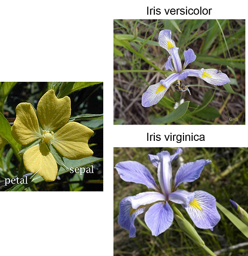

## The iris data

```r
load("iris.train.Rdata")
head(iris.train,5)
```

```
##    Sepal.Length Sepal.Width Petal.Length Petal.Width    Species
## 61          5.0         2.0          3.5         1.0 versicolor
## 62          5.9         3.0          4.2         1.5 versicolor
## 63          6.0         2.2          4.0         1.0 versicolor
## 64          6.1         2.9          4.7         1.4 versicolor
## 65          5.6         2.9          3.6         1.3 versicolor
```

## Pairs plot

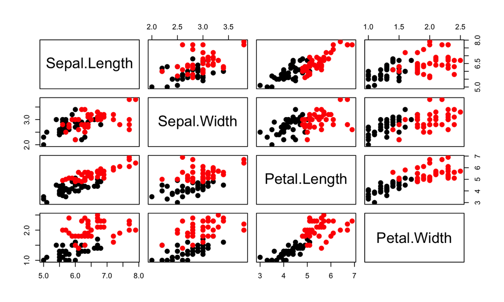

```r
pairs(iris.train[,-5], col=iris.train[,"Species"], pch=20, cex=2)
```

## Example 2: Lizards

We have in addition to sex measured \(k=3\) variables on lizards:

- Mass : Weight of lizard (in grams)
- SVL : Snout-vent length (in millimeters)
- HLS : Hind limb span (in millimeters)

Can we discriminate Sex on the basis of the body measures?

```r
load("Lizard.Rdata")
head(Lizard, 5)
```

```
##     Mass  SVL   HLS Sex
## 1  5.526 59.0 113.5   f
## 2 10.401 75.0 142.0   m
## 3  9.213 69.0 124.0   f
## 4  8.953 67.5 125.0   f
## 5  7.063 62.0 129.5   m
```

## Pairs plot - gender colored

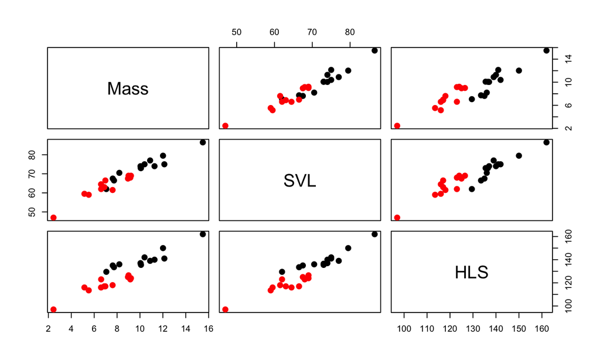

```r
pairs(Lizard[,-4], col=Lizard$Sex, pch=20,cex=2)
```

## Finding decision regions

In descriminant analysis we search for decision regions for the \(g\) known groups (classes).

Regions \(R_1, R_2, \ldots, R_g\)

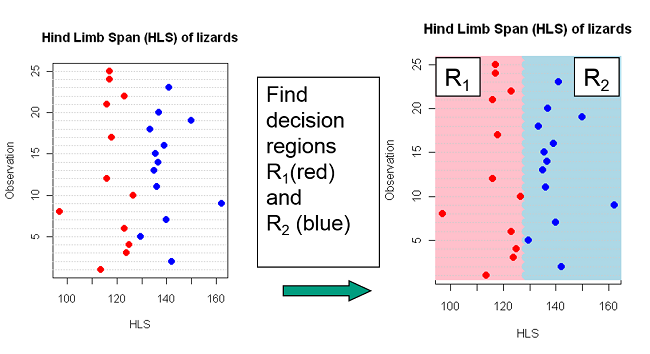

## Bivariate discrimination

Using HLS and Mass as predictors (\(k=2\))

Here we use a linear decision border. This may also be non-linear.

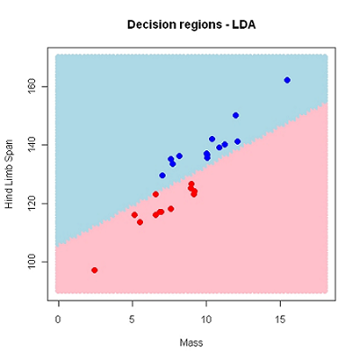

## Tri-variate discrimination

Using all variables (\(k=3\))

A linear discriminator is a flat plane in the 3D-space

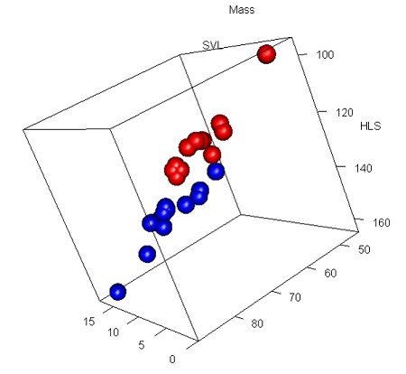

## Most probable group

- Perfect discrimination/classification may not be possible.
- The idea is to find decision regions \(R_1, R_2, \ldots, R_g\) that minimizes the probability of doing misclassification.
- *Intuitively we would allocate an observation to the group which is most probable given the observed value of the predictors*
- If, for example, the HLS of a new lizard is 130, it seems most probable based on previous data that the lizard is a male.

## Bayes rule

Let \(P(c_i|x_1,\ldots, x_p)\) be the probability of class \(i\) given the observed variables.

Then by Bayes rule:

\[P(c_i|x_1,\ldots, x_p) \propto f(x_1,\ldots, x_p|c_i)p_i\]

where \(p_i\) is the *a priori* probability of observing an object from class \(c_i\) and…

\(f(x_1,\ldots, x_p|c_i)\) is the likelihood (“probability”) of the observed data given class \(i\).

## A simple classification scheme

Allocate a new observation with observed variables \(x_1^*, x_2^*, \ldots x_p^*\) to the class which maximizes

\[f(x_1^*,\ldots, x_p^*)p_i\]

We need to estimate \(f(x_1^*,\ldots, x_p^*)\) from the training data and determine \(p_i\).

In linear discriminant analysis (LDA) we assume that \(f(x_1^*,\ldots, x_p^*)\) is a *normal distribution*, hence we must estimate the mean and (a common) variance for observations from each class.

Often we assume uniform prior: \(p_1 = p_2 = \cdots = p_g = 1/g\) .

## Lizards example

Assume equal probabilities for females (\(c_1\)) and males (\(c_2\)) *a priori*: \(p_1 = p_2 = 0.5\)

Assume \(x_1\) = HLS is the only predictor.

From the data we estimate \(\mu_1\), \(\mu_2\) and common \(\sigma^2\) for both classes. Let \(f_1\) and \(f_2\) denote these two normal distributions.

Classification rule: Classify a new lizard as *female* if

\[f_1(x_1^*)p_1 \geq f_2(x_1^*)p_2\]

or, alternatively if

\[\frac{f_1(x_1^*)p_1}{f_2(x_1^*)p_2}\geq 1\]

## Visual representation

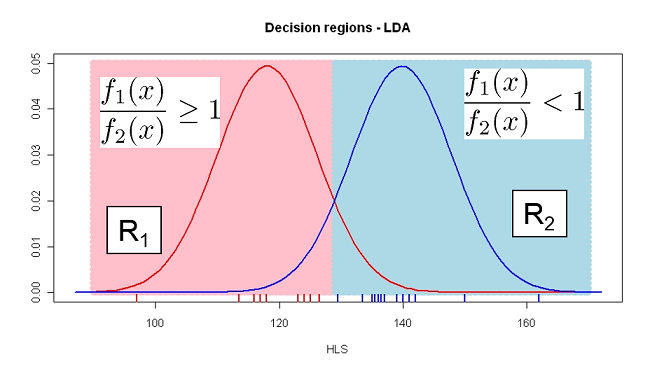

## LDA in R

The fit is presented as a *confusion matrix* and *accuracy* of classification

```r
library(MASS)
library(mixlm)
DAModel.1 <- lda(Sex~HLS, data=Lizard, prior=rep(0.5,2))
confusion(Lizard$Sex[], predict(DAModel.1)$class)  # confusion matrix
```

```
##          True
## Predicted  m  f
##   m       13  0
##   f        0 12
##   Total   13 12
##   Correct 13 12
##
## Proportions correct
## m f
## 1 1
##
## N correct/N total = 25/25 = 1
```

## Predicted classes and *Posterior probabilities*

R also returns the predicted classes (fitted) and \(P(c_i|x_1^*)\) also known as the *posterior* probability.

Remember \(P(c_i|x_1^*) \propto f_i(x_1^*)p_i\) for \(i=1,2\) here:

```r
predict(DAModel.1)$class  # Predicted classes
```

```
##  [1] f m f f m f m f m f m f m m m m f m m m f f m f f
## Levels: m f
```

```r
predict(DAModel.1)$posterior[1:5,]  # Posterior probabilities
```

```
##            m          f
## 1 0.00590689 0.99409311
## 2 0.98750273 0.01249727
## 3 0.16418501 0.83581499
## 4 0.21513565 0.78486435
## 5 0.55107831 0.44892169
```

## Other priors

If we assume males are more abundant: \(p_1 = 0.2\) and \(p_2=0.8\)

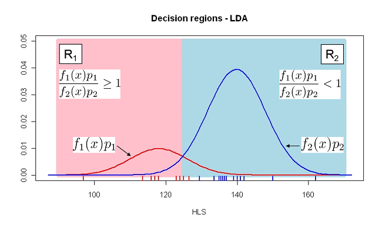

## LDA in R, other priors

```r
DAModel.2 <- lda(Sex~HLS, data=Lizard, prior=c(0.8,0.2))
confusion(Lizard$Sex[], predict(DAModel.2)$class)  # confusion matrix
```

```
##          True
## Predicted  m  f
##   m       13  2
##   f        0 10
##   Total   13 12
##   Correct 13 10
##
## Proportions correct
##         m         f
## 1.0000000 0.8333333
##
## N correct/N total = 23/25 = 0.92
```

## The default choice prior

In R the default choice of prior is “empirical”" which means that the priors are set equal to the group proportions in the data set

Hence, if there are \(n_i\) observations in group \(i\) and \(N = \sum_{i=1}^g n_i\) is the total observation number, then

\[\hat{p}_i = \frac{n_i}{N}\] This may be reasonable if one assumes that the sample sizes reflect population sizes.

## Bivariate LDA

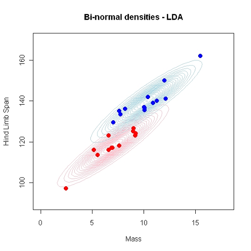

## … and in R

Follow demonstration

## Bivariate LDA - Decision regions

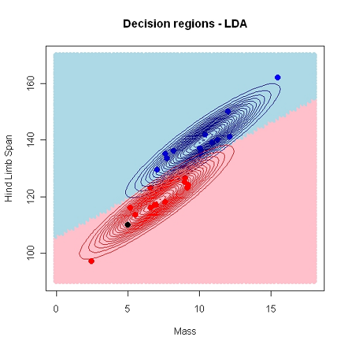

## Quadratic discriminant analysis

Quadratic DA (QDA) differs from LDA in two ways:

1. Class specific variances
2. Non-linear decision borders

## QDA in R

Choose “quadratic” instead of “linear”

Follow demonstration

## Bivariate QDA - Decision regions

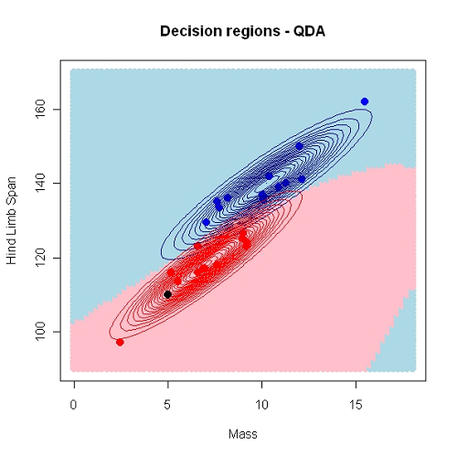

## Model selection/evaluation

- We often want to compare the performance of different classifiers.
- Many available statistics for this purpose, but we will consider the accuracy or the apparent error rate (APER)
- The performance of a classifier may as we’ve seen be summarized in a *confusion matrix*

## Example - SVL as predictor

```r
DAModel.4 <- lda(Sex~SVL, data=Lizard, prior=rep(0.5,2))
confusion(Lizard$Sex[], predict(DAModel.4)$class)  # confusion matrix
```

```
##          True
## Predicted  m  f
##   m       10  2
##   f        3 10
##   Total   13 12
##   Correct 10 10
##
## Proportions correct
##         m         f
## 0.7692308 0.8333333
##
## N correct/N total = 20/25 = 0.8
```

## Probabilities of misclassification - APER

\(P(female|male) = 3/13 = 0.23\)

\(P(male|female) = 2/12 = 0.17\)

Apparent error rate (APER) = \(\frac{3 + 2}{25} = 0.2\)

accuracy = \(1-APER = 0.8\)

## Example - SVL as predictor - LOOCV

```r
DAModel.9 <- lda(Sex~SVL, data=Lizard, prior=rep(0.5,2))
confusion(Lizard$Sex, lda(Sex~SVL, data=Lizard, prior=rep(0.5,2),
  CV=TRUE)$class)  # confusion matrix
```

```
##          True
## Predicted  m  f
##   m       10  3
##   f        3  9
##   Total   13 12
##   Correct 10  9
##
## Proportions correct
##         m         f
## 0.7692308 0.7500000
##
## N correct/N total = 19/25 = 0.76
```

Typically, as seen here, the accuracy goes down, and the APER increases when new samples are classified.